# HW1-Mobile Apps-Technical Document

# Team Solution

## Import data

```r
app <- read.csv("~/Desktop/HW 1/mobileApps.csv")
```

## Clean data

```r
# Cast proper data types (factors and dates)
app$crawl_date<-as.Date(parse_date_time(app$crawl_date, c('mdy')))
app$release_date<-as.Date(parse_date_time(app$release_date, c('mdy')))

app <- app %>%
  mutate_if(is.character, as.factor)

# Drop rows with NA region
app <- app %>% filter(region != "NA" )

# Impute app age
app$app_age <- as.numeric(difftime(app$crawl_date,app$release_date, units = "days"))

# Change average ratings 50->5
app$average_rating[app$average_rating== 50] <- 5

# Drop unnecessary/redundant columns - these are ill-defined or recalculated
# by us above
#app <- subset(app, select = -c(t_day, rank, app_age_current_version))
app <- subset(app, select = -c(t_day, crawl_date,app_age_current_version))

#clean category column
app$category<-app$category%>%str_replace("��", "")%>%str_replace(" > Notes", "")%>%str_replace(" > Radio", "")%>%str_replace(" > Magazines", "")

app<-app%>%mutate(across(category, str_trim))
app$category<-factor(app$category)
levels(app$category)
```

```
##  [1] "Education"         "Entertainment"     "Games"
##  [4] "Lifestyle"         "Multimedia"        "Music"
##  [7] "News & Magazines"  "Social"            "Social Networking"
## [10] "Utilities"
```

### Create normalization function

```r
normalize = function(x){
  return ((x-min(x)) / (max(x) - min(x)))}
```

*Success Measure, that equally weighs an app’s number of ratings with the app’s average rating and gives it a score between 0 and 1, with a value of 1 being the best.*

```r
# Create log of rating_count with +1 correction
app <- app %>% mutate(rating_count_log = log(app$rating_count + 1))

# Normalize rating count
app <- app %>% mutate(rcl_norm = normalize(rating_count_log))

# Normalize average rating
app <- app %>% mutate(ar_norm = normalize(average_rating))

# Create target variable with mean of normalized average_rating and log(rating_count)
app <- app %>% mutate(target = rcl_norm * ar_norm)

# Remove old measures and intermediary calculations
app <- subset(app, select= (-c(rating_count, average_rating, rcl_norm, rating_count_log, ar_norm)))
```

*Interperation from Approach:* We use number of ratings as a proxy for downloads and engagement,and average rating account for how satisfied customers were with each app.

### Convert to app level to perform clustering analysis

Assume if we group by device,app_store,is_US,developer,app_type,category,in_app_ads,in_app_purchase these dimensions, we will get the same app.

```r
app_new<-app%>%group_by(device,app_store,region,developer,app_type,category,in_app_ads,in_app_purchase)%>%summarise(mean_target=mean(target),mean_rank=mean(rank),mean_app_age=mean(app_age),price=mean(price),filesize=mean(filesize..MB.),num_screenshot=mean(num_screenshot),num_issues_reported=mean(num_issues_reported))
app_new<-as.data.frame(app_new)
```

```r
##Normalize continuous data in new dataframe
app_norm <- mutate_if(app_new, is.numeric, normalize)
```

```r
app_norm <- subset(app_norm, select = -c(developer))
```

```r
## Create dummies for binary categories
app<- app %>% mutate(device = ifelse(device == 'smart_phone', 0, 1)) # 1 for tablet, 0 for phone
app <- app %>% mutate(is_US = ifelse(region == 'US', 1, 0)) %>% subset(select = -c(region)) # is_US = 1 for US, 0 for CN
app<- app %>% mutate(in_app_ads = ifelse(in_app_ads == 'IN_APP_ADS', 1, 0)) # 1 for ads, 0 for no ads
app<- app %>% mutate(in_app_purchase = ifelse(in_app_purchase == 'NO_IN_APP_PURCHASE', 0, 1)) # 1 for in app purchase, 0 for no in app purchase
```

```r
## Create dummies for binary categories
app_norm<-app_norm %>% mutate(device = ifelse(device == 'smart_phone', 0, 1)) # 1 for tablet, 0 for phone
app_norm<-app_norm%>% mutate(is_US = ifelse(region == 'US', 1, 0)) %>% subset(select = -c(region)) # is_US = 1 for US, 0 for CN
app_norm<- app_norm %>% mutate(in_app_ads = ifelse(in_app_ads == 'IN_APP_ADS', 1, 0)) # 1 for ads, 0 for no ads
app_norm<- app_norm %>% mutate(in_app_purchase = ifelse(in_app_purchase == 'NO_IN_APP_PURCHASE', 0, 1)) # 1 for in app purchase, 0 for no in app purchase
```

```r
##one-hot encoding
app_norm<-app_norm%>% mutate(value = 1)  %>% spread(app_store, value,  fill = 0 )
app_norm<-app_norm%>% mutate(value = 1)  %>% spread(app_type, value,  fill = 0 )
app_norm<-app_norm%>% mutate(value = 1)  %>% spread(category, value,  fill = 0 )
```

*To find natural pattern in the dataset*

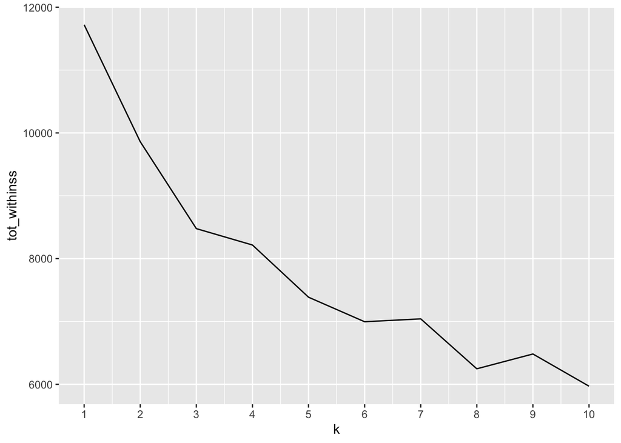

```r
set.seed(42)
# Use map_dbl to run many models with varying value of k (centers)
tot_withinss <- map_dbl(1:10,  function(k){
  model <- kmeans(x =app_norm, centers = k)
  model$tot.withinss
})

# Generate a data frame containing both k and tot_withinss
elbow_df <- data.frame(
  k = 1:10,
  tot_withinss = tot_withinss
)

# Plot the elbow plot
ggplot(elbow_df, aes(x = k, y = tot_withinss)) +
  geom_line() +
  scale_x_continuous(breaks = 1:10)
```

*Conclusions from Approach:* We choose elbow point where k equals 6.

```r
set.seed(42)

# Build a k-means model for the app_cluster with a k of 6
model_app <- kmeans(app_norm, centers = 6)

# Extract the vector of cluster assignments from the model
clust_app_new <- model_app$cluster

app_new<-app_new%>%mutate(class=clust_app_new)

# Calculate the size of each cluster
count(app_new, class)
```

```
##   class    n
## 1     1  591
## 2     2  365
## 3     3  520
## 4     4 1063
## 5     5 1257
## 6     6  516
```

```r
# Calculate the mean for each category
subset(select_if(app_new, is.numeric))%>%
  group_by(class) %>%
  summarise_all(list(mean))
```

```
## # A tibble: 6 × 8
##   class mean_target mean_rank mean_app_age price filesize num_screenshot
##   <int>       <dbl>     <dbl>        <dbl> <dbl>    <dbl>          <dbl>
## 1     1       0.303      212.         57.5 0.934     32.9           5.92
## 2     2       0.388      193.         90.3 1.13      28.9           7.32
## 3     3       0.562      183.         60.3 0.672     32.4           5.46
## 4     4       0.364      217.         69.3 1.21     134.            7.88
## 5     5       0.296      212.        129.  4.69     124.            7.47
## 6     6       0.397      199.         50.1 0         72.6           8.09
## # … with 1 more variable: num_issues_reported <dbl>
```

```r
app_new$class<-factor(app_new$class)
```

```r
summary(app_new[app_new$class == 3, ])
```

```
##          device          app_store   region                 developer
##  smart_phone:520   Amazon     :  3   CN:207   Disney             :  8
##  tablet     :  0   Apple      :  0   US:313   Electronic Arts Inc:  8
##                    Google Play:517            Rovio Mobile Ltd.  :  8
##                                               Autodesk Inc.      :  6
##                                               Gameloft           :  6
##                                               Google Inc.        :  6
##                                               (Other)            :478
##      app_type            category           in_app_ads
##  free    :358   Games        :264   IN_APP_ADS   :238
##  grossing:105   Utilities    : 90   NO_IN_APP_ADS:282
##  paid    : 57   Social       : 43
##                 Multimedia   : 42
##                 Lifestyle    : 40
##                 Entertainment: 22
##                 (Other)      : 19
##            in_app_purchase  mean_target       mean_rank        mean_app_age
##  NO_IN_APP_PURCHASE:335    Min.   :0.1765   Min.   :  2.429   Min.   :  0.00
##  PLUGIN_PURCHASE   :185    1st Qu.:0.4505   1st Qu.: 85.821   1st Qu.: 17.19
##                            Median :0.5724   Median :170.150   Median : 31.00
##                            Mean   :0.5615   Mean   :183.210   Mean   : 60.32
##                            3rd Qu.:0.6688   3rd Qu.:276.929   3rd Qu.: 60.12
##                            Max.   :0.9193   Max.   :408.000   Max.   :789.00
##
##      price            filesize       num_screenshot  num_issues_reported
##  Min.   : 0.0000   Min.   :   1.10   Min.   :2.000   Min.   :0
##  1st Qu.: 0.0000   1st Qu.:   4.30   1st Qu.:5.000   1st Qu.:0
##  Median : 0.0000   Median :   7.50   Median :5.000   Median :0
##  Mean   : 0.6718   Mean   :  32.42   Mean   :5.459   Mean   :0
##  3rd Qu.: 0.0000   3rd Qu.:  17.00   3rd Qu.:6.617   3rd Qu.:0
##  Max.   :17.4872   Max.   :1722.33   Max.   :8.000   Max.   :0
##
##  class
##  1:  0
##  2:  0
##  3:520
##  4:  0
##  5:  0
##  6:  0
##
```

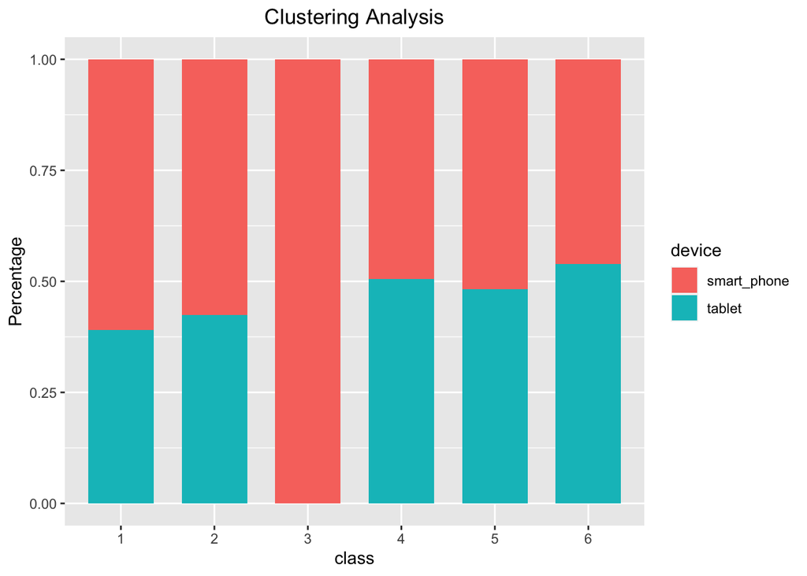

```r
ggplot(app_new, aes(x=class, fill = device))+
  geom_bar(width = 0.7, position='fill')+
  ylab('Percentage') +
  ggtitle('Clustering Analysis') +
  theme(plot.title = element_text(hjust = 0.5))
```

*Conclusions from Approach:* Cluster3 scored 42% higher on the success measure than the next closest alternative. CLuster3 is 100% of smartphone and 99.4% googleplay.

### Generating Graphs

*Check if top-performing apps are free or paid*

```r
app %>% arrange(desc(target)) %>% slice(1:100) %>% count(app_type == 'free')
```

```
##   app_type == "free"  n
## 1              FALSE 29
## 2               TRUE 71
```

*Interperation from Approach:* 71 of the top 100 applications by success measure on any App Store are the ones that are free to install.

*Conclusions from Approach:* Narrow down our analysis to free apps.

```r
dataGroupedByPlaystore <-app %>%
  mutate(is_US = as.factor(is_US)) %>%
  filter(app_store != 'Amazon') %>%
  select(app_store, category, is_US, target) %>%
  group_by(app_store, is_US, category) %>%
  summarise(target = mean(target))
```

*App performance for Categories on Apple Store*

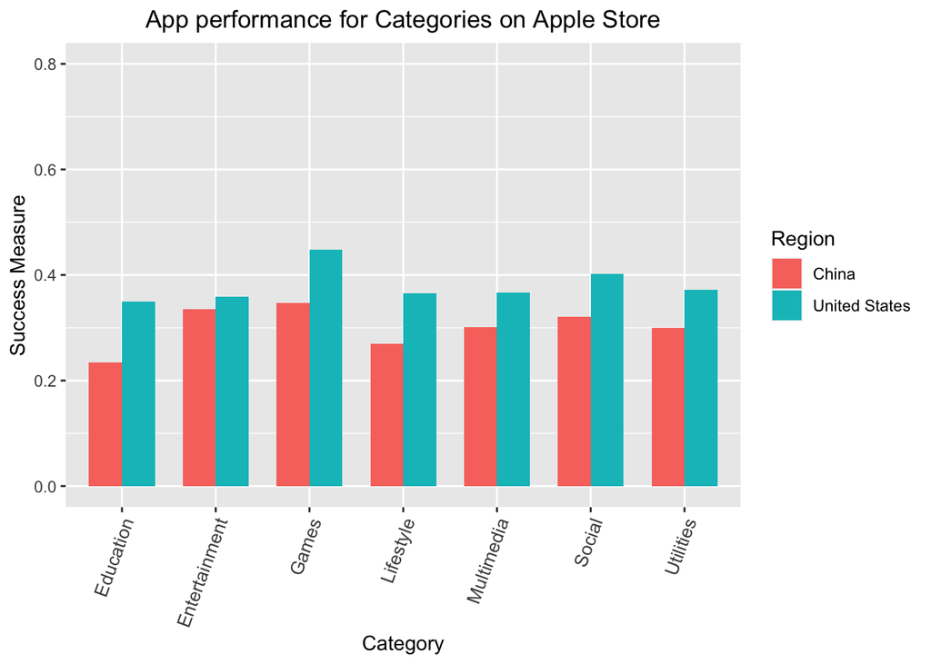

```r
dataGroupedByPlaystore %>%
  mutate(Region = if_else(is_US == 0, 'China', 'United States')) %>%
  filter(app_store == 'Apple') %>%
  ggplot(., aes(x = category, y = target, fill = Region)) +
      geom_bar(width = 0.7, stat = 'identity', position = position_dodge2(width = 0.001, preserve = "single", padding = -0.01))+
  ylim(0,0.8) +
  theme(axis.text.x = element_text(angle=70,size = 10,hjust = 1)) +
  xlab('Category') +
  ylab('Success Measure') +
  ggtitle('App performance for Categories on Apple Store') +
  theme(plot.title = element_text(hjust = 0.5))
```

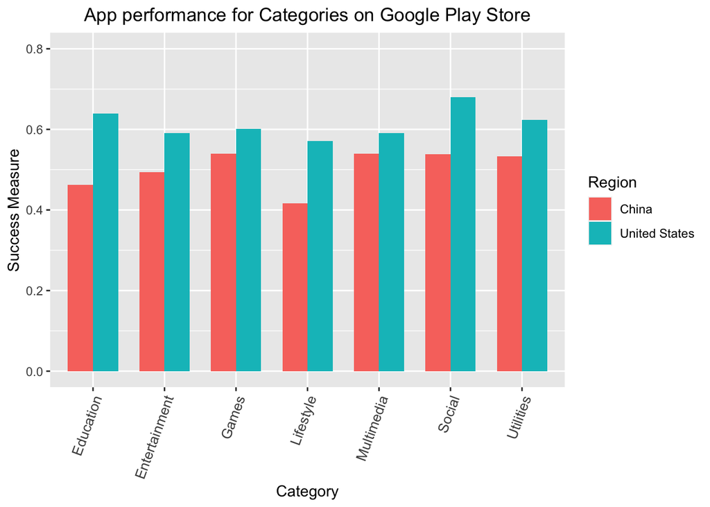

```r
dataGroupedByPlaystore %>%
  mutate(Region = if_else(is_US == 0, 'China', 'United States')) %>%
  filter(app_store == 'Google Play') %>%
  ggplot(., aes(x = category, y = target, fill = Region)) +
      geom_bar(width = 0.7, stat = 'identity', position = position_dodge2(width = 0.001, preserve = "single", padding = -0.01)) +
  ylim(0,0.8) +
  theme(axis.text.x = element_text(angle=70,size = 10,hjust = 1)) +
  xlab('Category') +
  ylab('Success Measure') +
  ggtitle('App performance for Categories on Google Play Store') +
  theme(plot.title = element_text(hjust = 0.5))
```

*Interperation from Approach:* Google Play store is dominating the market, both in the US and China, in terms of user engagement and satisfaction. Success metric numbers indicate that launching a free application on the Google Play store has a favorable chance to succeed in having a huge user base.Most notably, the Education category is scoring 40% better in the US than it is in China. Social and Lifestyle categories also suggest a similar pattern.

*Conclusions from Approach:* Narrow to Google Play store and Education category in US.

```r
a=app%>%
  filter(app_store == 'Google Play' & app_type == 'free' & is_US == 1)
summary(a)
```

```
##      device       rank             app_store    release_date
##  Min.   :0   Min.   :  3.0   Amazon     :  0   Min.   :2011-08-04
##  1st Qu.:0   1st Qu.: 80.0   Apple      :  0   1st Qu.:2012-10-29
##  Median :0   Median :152.0   Google Play:983   Median :2012-12-10
##  Mean   :0   Mean   :174.2                     Mean   :2012-11-03
##  3rd Qu.:0   3rd Qu.:271.0                     3rd Qu.:2012-12-20
##  Max.   :0   Max.   :408.0                     Max.   :2013-01-11
##
##                developer       app_type       price   filesize..MB.
##  Google Inc.        : 42   free    :983   Min.   :0   Min.   :  1.10
##  Rovio Mobile Ltd.  : 36   grossing:  0   1st Qu.:0   1st Qu.:  3.20
##  TeamLava Games     : 25   paid    :  0   Median :0   Median :  6.30
##  Mobage             : 19                  Mean   :0   Mean   : 10.92
##  Electronic Arts Inc: 17                  3rd Qu.:0   3rd Qu.: 15.00
##  Big Duck Games LLC : 14                  Max.   :0   Max.   :172.00
##  (Other)            :830
##  num_screenshot           category     in_app_ads     in_app_purchase
##  Min.   :2.000   Games        :497   Min.   :0.0000   Min.   :0.0000
##  1st Qu.:5.000   Utilities    :151   1st Qu.:0.0000   1st Qu.:0.0000
##  Median :5.000   Social       :107   Median :1.0000   Median :0.0000
##  Mean   :5.666   Multimedia   : 94   Mean   :0.6104   Mean   :0.3052
##  3rd Qu.:7.000   Lifestyle    : 64   3rd Qu.:1.0000   3rd Qu.:1.0000
##  Max.   :8.000   Entertainment: 48   Max.   :1.0000   Max.   :1.0000
##                  (Other)      : 22
##  num_issues_reported    app_age           target           is_US
##  Min.   :0           Min.   :  0.00   Min.   :0.2911   Min.   :1
##  1st Qu.:0           1st Qu.: 22.00   1st Qu.:0.5790   1st Qu.:1
##  Median :0           Median : 34.00   Median :0.6726   Median :1
##  Mean   :0           Mean   : 69.05   Mean   :0.6608   Mean   :1
##  3rd Qu.:0           3rd Qu.: 75.50   3rd Qu.:0.7406   3rd Qu.:1
##  Max.   :0           Max.   :530.00   Max.   :0.9200   Max.   :1
##
```

*Interperation from Approach:* we analyzed monetization factors and discerned that about 60% of these applications have in-app advertisements.

### To show the difference between application with in-app ads and without in-app ads

```r
new_data = app %>% arrange(desc(target)) %>% slice(1:100)
t.test(new_data$in_app_ads, app$in_app_ads)
```

```
##
##  Welch Two Sample t-test
##
## data:  new_data$in_app_ads and app$in_app_ads
## t = 5.3328, df = 99.72, p-value = 6.045e-07
## alternative hypothesis: true difference in means is not equal to 0
## 95 percent confidence interval:
##  0.1658348 0.3623373
## sample estimates:
## mean of x mean of y
##  0.590000  0.325914
```

```r
new_data1 = app %>% filter(in_app_ads == 0)
new_data2 = app %>% filter(in_app_ads == 1)
t.test(new_data1$target, new_data2$target)
```

```
##
##  Welch Two Sample t-test
##
## data:  new_data1$target and new_data2$target
## t = -33.336, df = 15027, p-value < 2.2e-16
## alternative hypothesis: true difference in means is not equal to 0
## 95 percent confidence interval:
##  -0.07922225 -0.07042321
## sample estimates:
## mean of x mean of y
## 0.3624402 0.4372630
```

### Conclusion and Recommendations

We recommend that our client creates a free smartphone education app in the US Google Play Store with in-app ads as a source of revenue.